# Webinar- spatial model

Alonzo

5/27/2020

## Checking the data

```r
colnames(K)
```

```
##  [1] "COUNTY"     "TOWN"       "VILLAGE"    "COUNTY_ID"  "TOWN_ID"
##  [6] "V_ID"       "VILLAGE_ID" "H_CNT"      "P_CNT"      "M_CNT"
## [11] "F_CNT"      "INFO_TIME"  "M_F_RAT"    "P_H_CNT"    "P_DEN"
## [16] "FLD1"       "FLD2"       "FLD3"       "FLD4"       "Pop20"
## [21] "Rate20"     "Hen20"      "Pop18"      "Rate18"     "Hen18"
## [26] "Delta"      "geometry"
```

```r
names(Income)[2] <- "V_ID"
Income <- filter(Income, 資料時間=="106Y")
K <- left_join(K,Income[,c(2,12)], by="V_ID")
names(K)[27] <- "Income"
```

- P_DEN: 人口密度  
  M_F_RAT: 性別比  
  FLD1: 扶養比  
  FLD2: 扶幼比  
  FLD3: 扶老比  
  FLD4: 老化指數  
  Income: 106年所得中位數  
  Delta: 得票率差

## Correlation of IV & DV

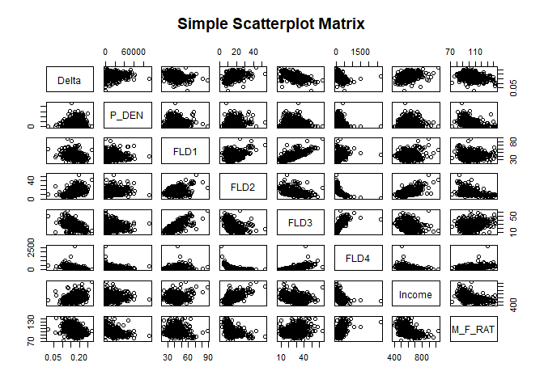

```r
n <- c("P_DEN","M_F_RAT","FLD1","FLD2","FLD3","FLD4","Income","Delta")
KK <- select(K,all_of(n))
KK$geometry <- NULL
KK<- na.omit(KK)
KK$Delta <- abs(KK$Delta) # 取絕對值
pairs(Delta~P_DEN+FLD1+FLD2+FLD3+FLD4+Income+M_F_RAT,data=KK,
      main="Simple Scatterplot Matrix")
```

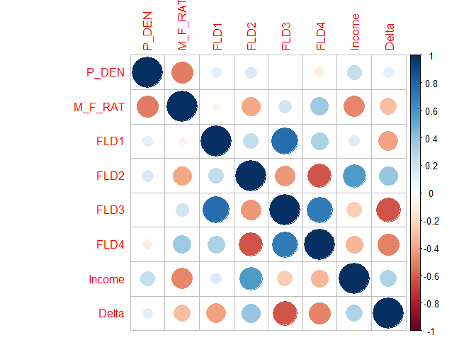

```r
M <- cor(KK)
corrplot(M)
```

## Spatial Model expression

- 1. The value of X’s in a region might affect (or be related to ) the value of y in a neighboring region (lag X)

$$\mathrm Y= X\beta+WX\theta+\varepsilon$$

## Make the weights matrix

$$W=
\left[
\begin{matrix}
W_{11} & W_{12} & \cdots & W_{1n} \\
W_{21} & W_{22} & \cdots & W_{2n} \\
\vdots & \vdots & \ddots & \vdots \\
W_{n1} & W_{n2} & \cdots & W_{nn} \\
\end{matrix}
\right]$$

```r
KK <- select(K,all_of(n));KK$Delta <- abs(KK$Delta); KK <- na.omit(KK)
queen.nb=poly2nb(KK)
queen.listw=nb2listw(queen.nb)
listw1= queen.listw
```

## OLS Model

```r
reg.eq1=Delta~P_DEN+M_F_RAT+FLD1+FLD2+FLD3+FLD4+Income
reg1=lm(reg.eq1,data=KK)
summary(reg1)
```

```
##
## Call:
## lm(formula = reg.eq1, data = KK)
##
## Residuals:
##       Min        1Q    Median        3Q       Max
## -0.159021 -0.010123  0.002057  0.012942  0.071182
##
## Coefficients:
##                   Estimate     Std. Error t value  Pr(>|t|)
## (Intercept)  0.24723872309  0.01434366643  17.237   < 2e-16 ***
## P_DEN        0.00000005840  0.00000006781   0.861    0.3893
## M_F_RAT     -0.00038079820  0.00009448575  -4.030 0.0000605 ***
## FLD1        -0.11246457202  0.14921481701  -0.754    0.4512
## FLD2         0.11272420732  0.14920227907   0.756    0.4501
## FLD3         0.11040674541  0.14921590108   0.740    0.4595
## FLD4         0.00000461586  0.00000782765   0.590    0.5556
## Income       0.00002700209  0.00001309659   2.062    0.0395 *
## ---
## Signif. codes:  0 '***' 0.001 '**' 0.01 '*' 0.05 '.' 0.1 ' ' 1
##
## Residual standard error: 0.02185 on 883 degrees of freedom
## Multiple R-squared:  0.4375, Adjusted R-squared:  0.433
## F-statistic: 98.11 on 7 and 883 DF,  p-value: < 2.2e-16
```

## Spatially Lagged X (SLX) Model

```r
reg2=lmSLX(reg.eq1,data=KK, listw1)
summary(reg2)
```

```
##
## Call:
## lm(formula = formula(paste("y ~ ", paste(colnames(x)[-1], collapse = "+"))),
##     data = as.data.frame(x), weights = weights)
##
## Residuals:
##       Min        1Q    Median        3Q       Max
## -0.156006 -0.009448  0.002053  0.013054  0.071183
##
## Coefficients:
##                   Estimate     Std. Error t value Pr(>|t|)
## (Intercept)  0.34853961682  0.02739488380  12.723  < 2e-16 ***
## P_DEN        0.00000008264  0.00000009535   0.867 0.386354
## M_F_RAT     -0.00028621248  0.00010904209  -2.625 0.008821 **
## FLD1        -0.13721135671  0.14841326052  -0.925 0.355469
## FLD2         0.13752957936  0.14839875057   0.927 0.354308
## FLD3         0.13514708959  0.14841444210   0.911 0.362753
## FLD4         0.00000890240  0.00000830614   1.072 0.284112
## Income       0.00003886484  0.00001506132   2.580 0.010029 *
## lag.P_DEN   -0.00000023513  0.00000014408  -1.632 0.103063
## lag.M_F_RAT -0.00068827884  0.00018939885  -3.634 0.000295 ***
## lag.FLD1     0.30334001496  0.32382059148   0.937 0.349144
## lag.FLD2    -0.30315646922  0.32379289849  -0.936 0.349394
## lag.FLD3    -0.30319244816  0.32382501230  -0.936 0.349385
## lag.FLD4    -0.00000734255  0.00001426463  -0.515 0.606866
## lag.Income  -0.00008730923  0.00002457309  -3.553 0.000401 ***
## ---
## Signif. codes:  0 '***' 0.001 '**' 0.01 '*' 0.05 '.' 0.1 ' ' 1
##
## Residual standard error: 0.02166 on 876 degrees of freedom
## Multiple R-squared:  0.452,  Adjusted R-squared:  0.4432
## F-statistic: 51.61 on 14 and 876 DF,  p-value: < 2.2e-16
```

```r
impacts(reg2,listw=listw1)
```

```
## Impact measures (SLX, estimable):
##                    Direct         Indirect            Total
## P_DEN    0.00000008264195 -0.0000002351271 -0.0000001524851
## M_F_RAT -0.00028621248496 -0.0006882788355 -0.0009744913205
## FLD1    -0.13721135670849  0.3033400149647  0.1661286582562
## FLD2     0.13752957935727 -0.3031564692182 -0.1656268898610
## FLD3     0.13514708958668 -0.3031924481598 -0.1680453585732
## FLD4     0.00000890240233 -0.0000073425493  0.0000015598530
## Income   0.00003886483971 -0.0000873092268 -0.0000484443871
```

## Spatial Autoregressive (SAR) Model

- 2. The value of y in a region might affect (or be related to ) the value of y in a neighboring region (lag y)

$$\mathrm Y=\rho WY+X\beta+\varepsilon$$

```r
reg3=lagsarlm(reg.eq1,data= KK, listw1)
summary(reg3)
```

```
##
## Call:lagsarlm(formula = reg.eq1, data = KK, listw = listw1)
##
## Residuals:
##        Min         1Q     Median         3Q        Max
## -0.1417180 -0.0101967  0.0019296  0.0128910  0.0687852
##
## Type: lag
## Coefficients: (asymptotic standard errors)
##                    Estimate      Std. Error z value  Pr(>|z|)
## (Intercept)  0.164480328888  0.016092118937 10.2212 < 2.2e-16
## P_DEN        0.000000048108  0.000000064211  0.7492  0.453723
## M_F_RAT     -0.000261378597  0.000089694280 -2.9141  0.003567
## FLD1        -0.149004438936  0.140969248589 -1.0570  0.290512
## FLD2         0.149234655001  0.140957382890  1.0587  0.289726
## FLD3         0.147313538171  0.140970469156  1.0450  0.296025
## FLD4         0.000007557672  0.000007397892  1.0216  0.306971
## Income       0.000031165895  0.000012375427  2.5184  0.011790
##
## Rho: 0.3304, LR test value: 74.784, p-value: < 2.22e-16
## Asymptotic standard error: 0.037809
##     z-value: 8.7386, p-value: < 2.22e-16
## Wald statistic: 76.363, p-value: < 2.22e-16
##
## Log likelihood: 2183.759 for lag model
## ML residual variance (sigma squared): 0.00042627, (sigma: 0.020646)
## Number of observations: 891
## Number of parameters estimated: 10
## AIC: -4347.5, (AIC for lm: -4274.7)
## LM test for residual autocorrelation
## test value: 24.974, p-value: 0.00000058122
```

```r
impacts(reg3,listw=listw1)
```

```
## Impact measures (lag, exact):
##                    Direct          Indirect             Total
## P_DEN    0.00000004917012  0.00000002267561  0.00000007184572
## M_F_RAT -0.00026714861700 -0.00012319995808 -0.00039034857508
## FLD1    -0.15229376200236 -0.07023276147212 -0.22252652347448
## FLD2     0.15252906016486  0.07034127307170  0.22287033323656
## FLD3     0.15056553403468  0.06943576085286  0.22000129488754
## FLD4     0.00000772451052  0.00000356228448  0.00001128679500
## Income   0.00003185389289  0.00001468994417  0.00004654383706
```

## 「The work of science is to substitute facts for appearances，and demonstrations for impressions. —— John Ruskin」